# Algoritmos de clasificacion : K-NN, arboles de decision simples y multiples (random forest)

UOC - Master BI - Business Analytics (Lola Fernanda Romero)

Marzo del 2017

# 1 Base teorica

Esta practica se basa en una de las aplicaciones de **algoritmos de clasificacion**, desarrolladas con **K-NN** y **arboles de decision**.

# 2 Caso de estudio: — Clasificacion red de ventas Bodegas Mureda —

Formamos parte de la Direccion Comercial de la Bodega de vinos **Mureda** y queremos analizar la actividad de nuestra red de ventas, formada por tres categorias de comerciales (A, B y C). Para ello, estamos interesados en conocer si existen diferencias en la actividad generada por cada uno de los comerciales y, en caso afirmativo, identificar cuales son las variables que mas contribuyen a dichas diferencias y si podemos predecir a que categoria de comercial pertenece un nuevo empleado en funcion de su actividad.

Para ello, nuestro equipo de analisis dispone de un fichero con informacion de 150 clientes que recoge estadisticas de actividad de los tres grupos de Comerciales, a razon de 50 registros por grupo de comercial. El fichero contiene informacion de las siguientes variables:

- *Importe*: Volumen de Facturacion en el Cliente (vinculado a una categoria de Comercial)
- *Margen*: Margen por Cliente (vinculado a una categoria de Comercial)
- *Km*: Kilometros recorridos para visitar al Cliente.
- *Visitas*: Visitas realizadas al Cliente.
- *Comercial*: Categoria de comercial asignada al cliente (Toma valores A, B o C)

Una vez definidos los objetivos de nuestra investigacion, nuestro departamento de analisis nos propone desarrollar un proceso de clasificacion que aplique tres tipos de algoritmos complementarios: K-NN, arboles de decision simples y arboles de clasificacion multiples (random forest) sobre nuestro fichero de datos.

# 3 Carga de paquetes y del fichero de datos

Empezaremos por cargar los packages R que necesitaremos tener en memoria.

```r
#install.packages("ggplot2")
#install.packages("rpart.plot")
#install.packages("useful")
#install.packages("randomForest")

# Para representar graficamente la relacion entre variables
library("ggplot2")
# Para clasificar con K-NN
library("class")
# Para clasificar con rpart
library("rpart")
library("rpart.plot")
# Para clasificar con randomForest
library("useful")
library("randomForest")

setwd("~/UOC/Business Analytics")

#cargamos el fichero de datos que utilizamos para desarrollar la PEC 2
nombreruta_PEC2 <- paste(getwd(),"/PEC2.csv", sep = "")

Data_PEC2 <- read.csv(nombreruta_PEC2, encoding="UTF-8",
                     header=TRUE, sep=",", na.strings="NA", dec=".", strip.white=TRUE)
```

# 4 Analisis univariable y bivariable del fichero

Aplicamos la siguiente secuencia de calculos y representaciones graficas.

1. Estadisticos descriptivos de las variables
2. Representacion grafica de cada una de las variables
3. Estudio de la relacion entre las variables cuantitativas
4. Estudio de la existencia de diferencias por comercial

```r
# 1.Calculamos los descriptivos univariables de las variables del fichero
summary(Data_PEC2) #Estadisticos descriptivos basicos de las variables
```

```
##     Ingresos        Margen            Km           Visitas      Comercial
##  Min.   :4300   Min.   :200.0   Min.   :10.00   Min.   : 1.00   A:50
##  1st Qu.:5100   1st Qu.:280.0   1st Qu.:16.00   1st Qu.: 3.00   B:50
##  Median :5800   Median :300.0   Median :43.50   Median :13.00   C:50
##  Mean   :5843   Mean   :305.4   Mean   :37.59   Mean   :11.99
##  3rd Qu.:6400   3rd Qu.:330.0   3rd Qu.:51.00   3rd Qu.:18.00
##  Max.   :7900   Max.   :440.0   Max.   :69.00   Max.   :25.00
```

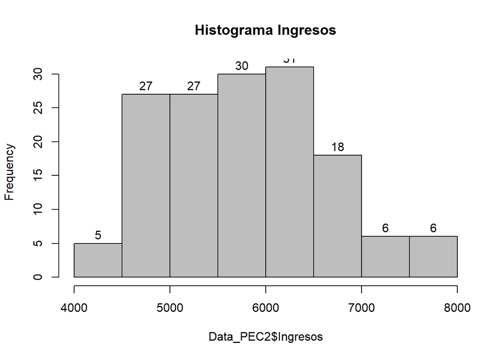

```r
# 2.Representamos graficamente las variables del fichero mediante histogramas

#Histograma Ingresos
f1 <- hist(Data_PEC2$Ingresos, main="Histograma Ingresos", col = "gray", labels = TRUE)
```

```r
f1
```

```
## $breaks
## [1] 4000 4500 5000 5500 6000 6500 7000 7500 8000
##
## $counts
## [1]  5 27 27 30 31 18  6  6
##
## $density
## [1] 6.666667e-05 3.600000e-04 3.600000e-04 4.000000e-04 4.133333e-04
## [6] 2.400000e-04 8.000000e-05 8.000000e-05
##
## $mids
## [1] 4250 4750 5250 5750 6250 6750 7250 7750
##
## $xname
## [1] "Data_PEC2$Ingresos"
##
## $equidist
## [1] TRUE
##
## attr(,"class")
## [1] "histogram"
```

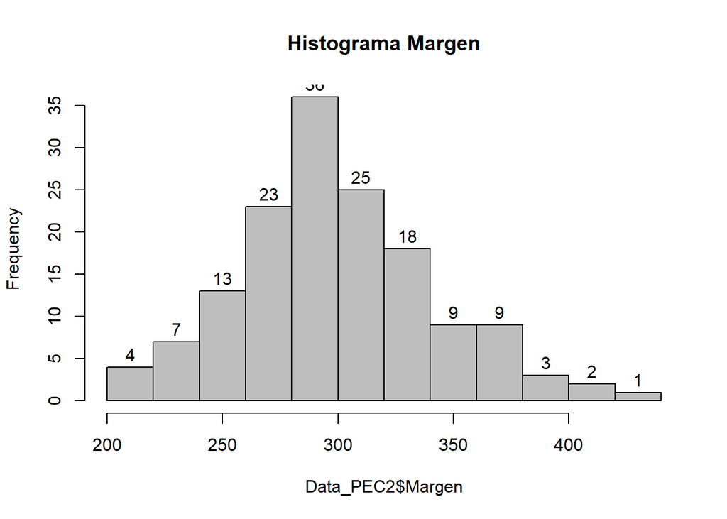

```r
#Histograma Margen
f2 <- hist(Data_PEC2$Margen, main="Histograma Margen", col = "gray", labels = TRUE)
```

```r
f2
```

```
## $breaks
##  [1] 200 220 240 260 280 300 320 340 360 380 400 420 440
##
## $counts
##  [1]  4  7 13 23 36 25 18  9  9  3  2  1
##
## $density
##  [1] 0.0013333333 0.0023333333 0.0043333333 0.0076666667 0.0120000000
##  [6] 0.0083333333 0.0060000000 0.0030000000 0.0030000000 0.0010000000
## [11] 0.0006666667 0.0003333333
##
## $mids
##  [1] 210 230 250 270 290 310 330 350 370 390 410 430
##
## $xname
## [1] "Data_PEC2$Margen"
##
## $equidist
## [1] TRUE
##
## attr(,"class")
## [1] "histogram"
```

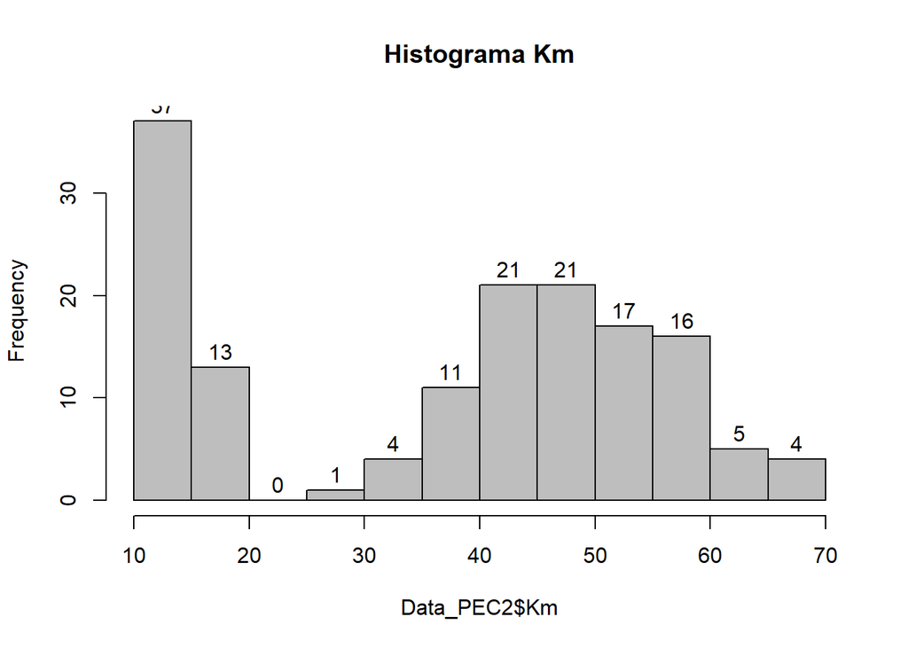

```r
#Histograma Km
f3 <- hist(Data_PEC2$Km, main="Histograma Km", col = "gray", labels = TRUE)
```

```r
f3
```

```
## $breaks
##  [1] 10 15 20 25 30 35 40 45 50 55 60 65 70
##
## $counts
##  [1] 37 13  0  1  4 11 21 21 17 16  5  4
##
## $density
##  [1] 0.049333333 0.017333333 0.000000000 0.001333333 0.005333333
##  [6] 0.014666667 0.028000000 0.028000000 0.022666667 0.021333333
## [11] 0.006666667 0.005333333
##
## $mids
##  [1] 12.5 17.5 22.5 27.5 32.5 37.5 42.5 47.5 52.5 57.5 62.5 67.5
##
## $xname
## [1] "Data_PEC2$Km"
##
## $equidist
## [1] TRUE
##
## attr(,"class")
## [1] "histogram"
```

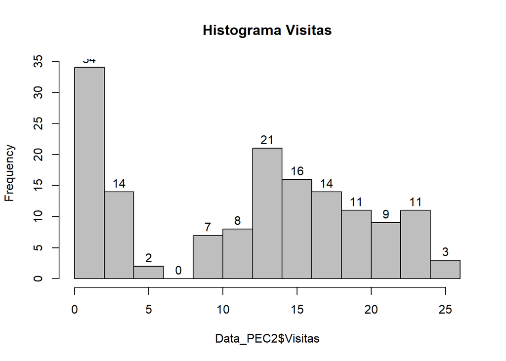

```r
#Histograma Visitas
f4 <- hist(Data_PEC2$Visitas, main="Histograma Visitas", col = "gray", labels = TRUE)
```

```r
f4
```

```
## $breaks
##  [1]  0  2  4  6  8 10 12 14 16 18 20 22 24 26
##
## $counts
##  [1] 34 14  2  0  7  8 21 16 14 11  9 11  3
##
## $density
##  [1] 0.113333333 0.046666667 0.006666667 0.000000000 0.023333333
##  [6] 0.026666667 0.070000000 0.053333333 0.046666667 0.036666667
## [11] 0.030000000 0.036666667 0.010000000
##
## $mids
##  [1]  1  3  5  7  9 11 13 15 17 19 21 23 25
##
## $xname
## [1] "Data_PEC2$Visitas"
##
## $equidist
## [1] TRUE
##
## attr(,"class")
## [1] "histogram"
```

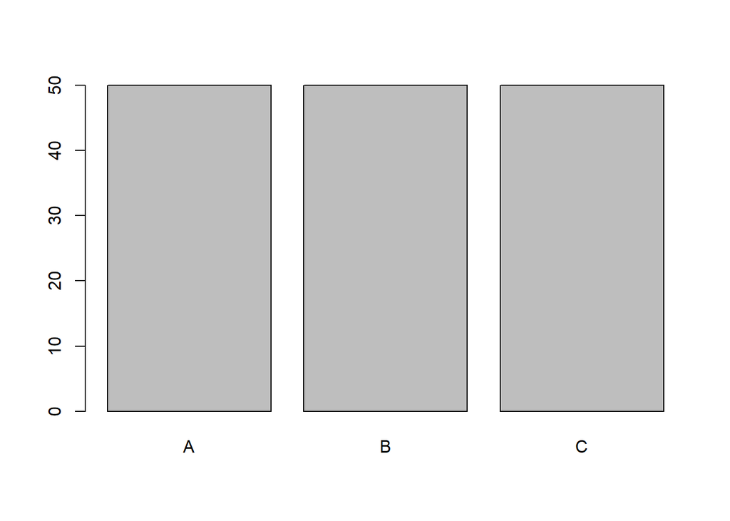

```r
#Histograma Comercial
f5 <- plot(Data_PEC2$Comercial)
```

```r
f5
```

```
##      [,1]
## [1,]  0.7
## [2,]  1.9
## [3,]  3.1
```

Las variables cuantitativas presentan dos distribuciones diferenciadas:

- *Importe* y *Margen* presentan una distribucion similar a una campana de *Gauss*, algo mas concentrada en el caso de *Margen*
- *Km* y *Visitas* presentan una distribucion muy similar. Con una alta concentracion para valores bajos que desciende rapidamente para volver a crecer siguiendo una campana de *Gauss* a partir del tercer valor de la serie.

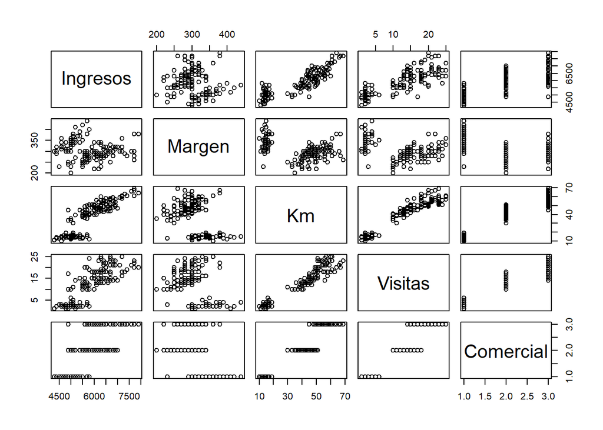

```r
# 3.Estudiamos la relacion existente entre las variables del fichero

# Estudiamos la relacion entre variables mediante graficos de dispersion
f6<- plot(Data_PEC2)
```

```r
f6
```

```r
# Estudiamos la relacion entre variables cuantitativas mediante correlaciones
cor(Data_PEC2[,c("Ingresos","Margen","Km","Visitas")], use="complete")
```

```
##            Ingresos     Margen         Km    Visitas
## Ingresos  1.0000000 -0.1093692  0.8717542  0.8179536
## Margen   -0.1093692  1.0000000 -0.4205161 -0.3565441
## Km        0.8717542 -0.4205161  1.0000000  0.9627571
## Visitas   0.8179536 -0.3565441  0.9627571  1.0000000
```

Analizando los graficos de dispersion, apuntamos una fuerte relacion entre *Visitas*-*Km*, *Ingresos*-*Km*, *Margen*-*Km* e *Ingresos*-*Visitas* que podemos validar con el coeficiente de correlacion, estadistico que toma valores entre -1 y 1 y que mide la fuerza con la que dos variables quedan interrelacionadas (proximo a 1 cuando la relacion es fuertemente directa y proximo a -1 cuando la relacion es fuertemente inversa)

- Coeficiente de Correlacion *Visitas*-*Km* -> (0,96)
- Coeficiente de Correlacion *Ingresos*-*Km* -> (0,87)
- Coeficiente de Correlacion *Ingresos*-*Visitas* -> (0,82)
- Coeficiente de Correlacion *Margen*-*Km* -> (-0,42)

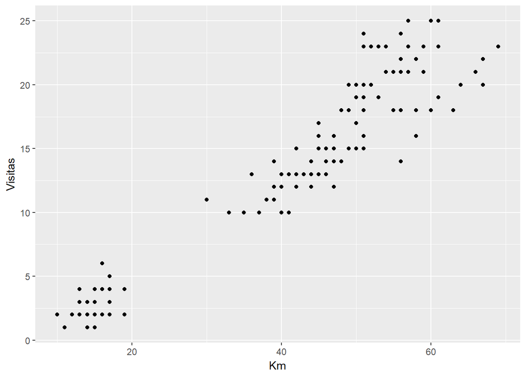

```r
# Estudiamos la relacion entre variables Km y Visitas
f7<-ggplot(Data_PEC2, aes(x=Km, y=Visitas)) + geom_point()
f7
```

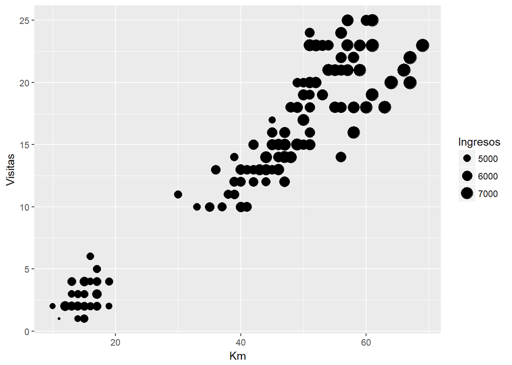

```r
# Estudiamos la relacion entre variables Km y Visitas con tamano ingresos
f8<-ggplot(Data_PEC2, aes(x=Km, y=Visitas)) + geom_point(aes(size=Ingresos))
f8
```

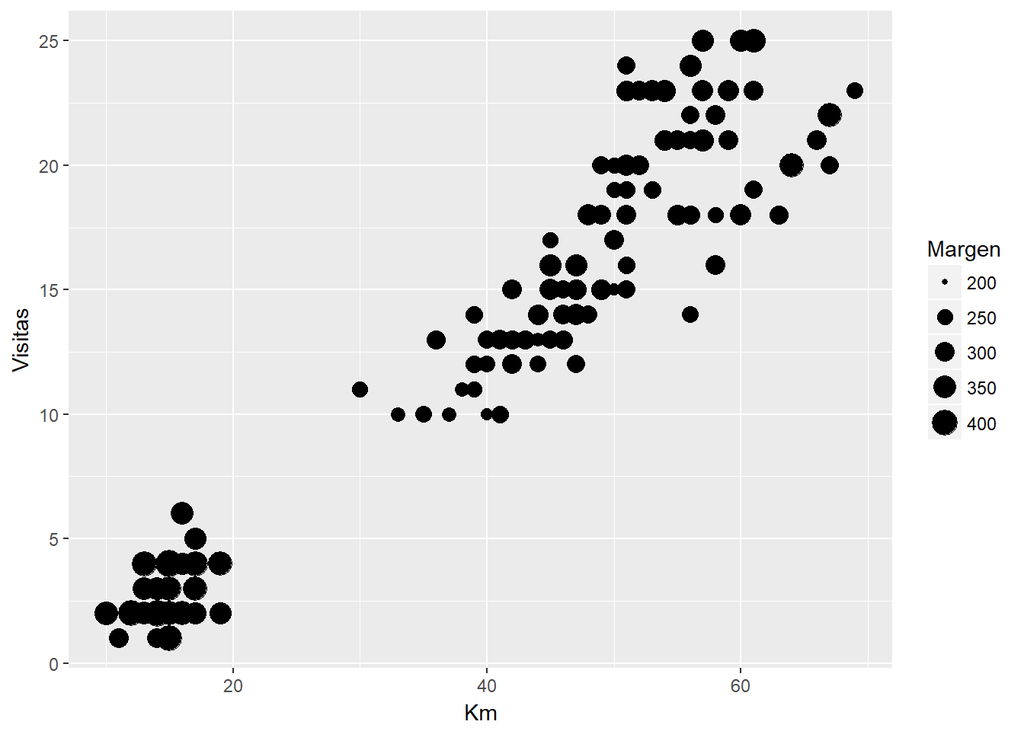

```r
# Relacion entre variables Km y Visitas con tamaÃ±o margen
f9<-ggplot(Data_PEC2, aes(x=Km, y=Visitas)) + geom_point(aes(size=Margen))
f9
```

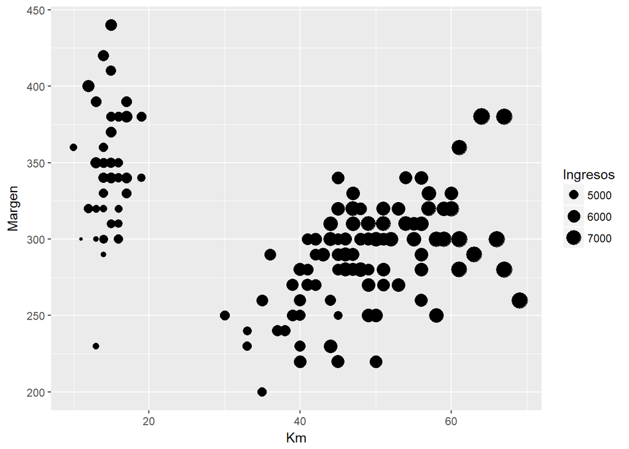

```r
# Relacion entre variables Km y Visitas con tamaÃ±o margen
fA<-ggplot(Data_PEC2, aes(x=Km, y=Margen)) + geom_point(aes(size=Ingresos))
fA
```

```r
# 3.Estudiamos la existencia de diferencias por Comercial

# promedio variables por comercial
tapply(Data_PEC2$Ingresos,Data_PEC2$Comercial,mean)
```

```
##    A    B    C
## 5006 5936 6588
```

```r
tapply(Data_PEC2$Margen,Data_PEC2$Comercial,mean)
```

```
##     A     B     C
## 341.8 277.0 297.4
```

```r
tapply(Data_PEC2$Km,Data_PEC2$Comercial,mean)
```

```
##     A     B     C
## 14.64 42.60 55.52
```

```r
tapply(Data_PEC2$Visitas,Data_PEC2$Comercial,mean)
```

```
##     A     B     C
##  2.44 13.26 20.26
```

Vemos que existen diferencias remarcables en el promedio de cada una de las variables para cada Comercial:

Graficamos a continuacion las variables cuantitativas diferenciando por Comercial.

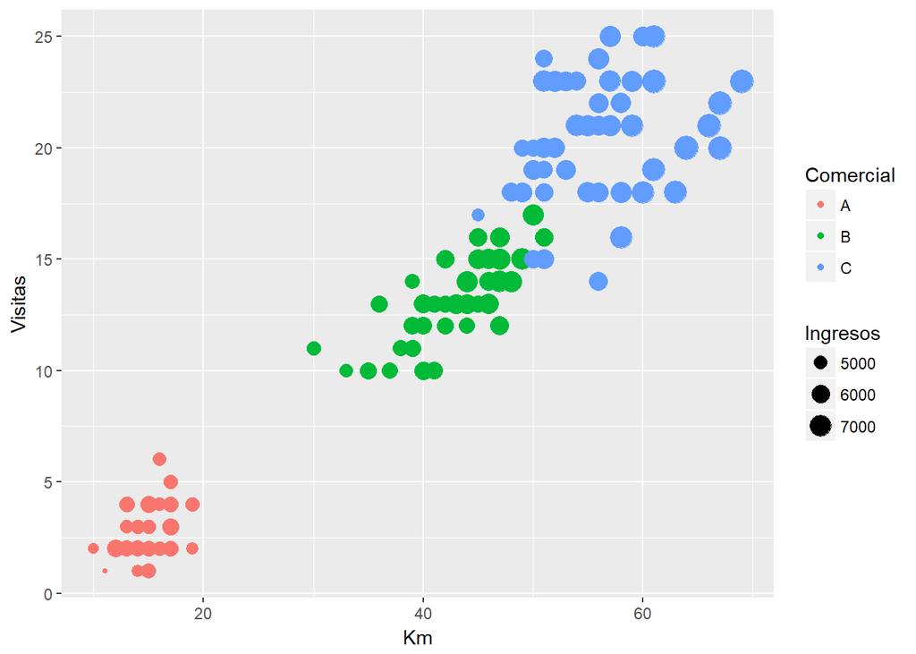

```r
# Relacion entre variables Km y Visitas con tamaÃ±o ingresos y Color segun Comercial
f10<-ggplot(Data_PEC2, aes(x=Km, y=Visitas, color=Comercial)) + geom_point(aes(size=Ingresos))
f10
```

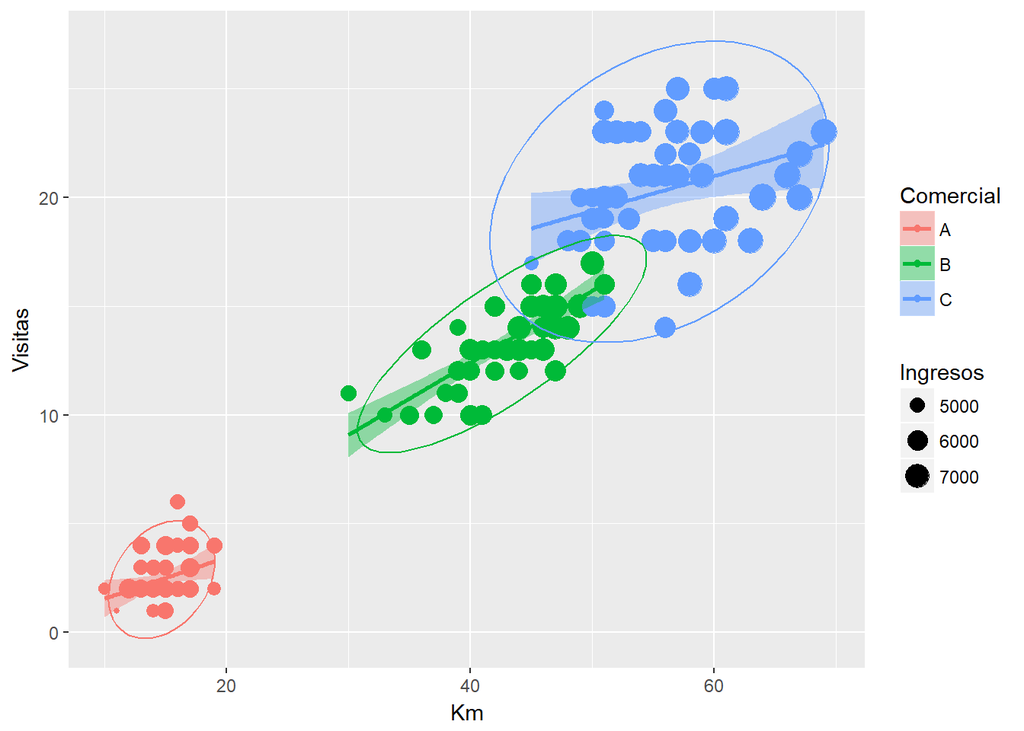

```r
# Relacion entre variables Km y Visitas con tamaÃ±o ingresos y Color segun Comercial, linea tendencia y elipse
f11<-ggplot(Data_PEC2, aes(x=Km, y=Visitas, color=Comercial)) + geom_point(aes(size=Ingresos)) +
  geom_smooth(method=lm, aes(fill=Comercial))+ stat_ellipse(type = "norm")
f11
```

Identificamos un comportamiento diferenciado donde *Km* y *Visitas* ya que son las variables que presentan una mayor capacidad de diferenciacion.

# 5 Proceso de clasificacion mediante K-NN.

Una vez analizado descriptivamente el fichero, consideramos necesario evaluar la capacidad predictiva de tres modelos predictivos:

- K-Vecino proximo (*K-NN*)
- arboles de decision simples
- arboles de decision multiples (random forest)

Con dicho objetivo, aplicaremos los algoritmos siguiendo la siguiente secuencia:

6 Clasificacion de los clientes con *K-NN*

```
 6.1 Construccion del Modelo de clasificacion con _K-NN_

 6.2 Validacion del Modelo de clasificacion con _K-NN_
```

7 Clasificacion de los clientes con arboles de decision simples

```
 7.1 Construccion del Modelo de clasificacion con el paquete _rpart_

 7.2 Validacion del Modelo de clasificacion con el paquete _rpart_
```

8 Clasificacion de los clientes con arboles de decision multiples (*random forest*)

```
 8.1 Construccion del Modelo de clasificacion con el paquete _randomForest_

 8.2 Validacion del Modelo de clasificacion con el paquete _randomForest_
```

## 5.1 Construccion del juego de datos de entrenamiento

Construimos un **juego de datos de entrenamiento** con el 70% de registros para construir los modelos y un **juego de datos de pruebas** con el 30% de registros restantes para validar los modelos.

```r
# Dividimos el fichero en 70% entreno y 30% validacion  #
set.seed(1234)
ind <- sample(2, nrow(Data_PEC2), replace=TRUE, prob=c(0.7, 0.3))
trainData <- Data_PEC2[ind==1,]
testData <- Data_PEC2[ind==2,]
```

## 5.2 Clasificacion de los Comerciales con *K-NN*

**Aplicamos el modelo K-NN**, pasandole como parametros la matriz de entrenamiento compuesta por las 4 variables cuantitativas : *Importe*, *Margen*, *Km* y *Visitas*. No le pasamos el campo *Comercial* porque precisamente es el campo que el algoritmo debe predecir.

Dado que el modelo *K-NN* permite replicar el modelo para *n* valores diferentes de *k*, repetimos el analisis para *k*=1,2,3 y 4.

```r
# Aplicamos el algoritmo K-NN seleccionando 1 como k inicial
KnnTestPrediccion_k1 <- knn(trainData[,1:4],testData[,1:4], trainData$Comercial , k = 1, prob = TRUE )
# Visualizamos una matriz de confusion
table ( testData$Comercial , KnnTestPrediccion_k1 )
```

```
##    KnnTestPrediccion_k1
##      A  B  C
##   A 10  0  0
##   B  0  9  3
##   C  0  6 10
```

```r
# Calculamos el % de aciertos para k=1
sum(KnnTestPrediccion_k1 == testData$Comercial)/ length(testData$Comercial)*100
```

```
## [1] 76.31579
```

```r
# Aplicamos el algoritmo K-NN seleccionando 2 como k inicial
KnnTestPrediccion_k2 <- knn(trainData[,1:4],testData[,1:4], trainData$Comercial , k = 2, prob = TRUE )
# Visualizamos una matriz de confusion
table ( testData$Comercial , KnnTestPrediccion_k2 )
```

```
##    KnnTestPrediccion_k2
##      A  B  C
##   A 10  0  0
##   B  2  8  2
##   C  0  7  9
```

```r
# Calculamos el % de aciertos para k=2
sum(KnnTestPrediccion_k2 == testData$Comercial)/ length(testData$Comercial)*100
```

```
## [1] 71.05263
```

```r
# Aplicamos el algoritmo K-NN seleccionando 3 como k inicial
KnnTestPrediccion_k3 <- knn(trainData[,1:4],testData[,1:4], trainData$Comercial , k = 3, prob = TRUE )
# Visualizamos una matriz de confusion
table ( testData$Comercial , KnnTestPrediccion_k3 )
```

```
##    KnnTestPrediccion_k3
##      A  B  C
##   A 10  0  0
##   B  2  7  3
##   C  0  8  8
```

```r
# Calculamos el % de aciertos para k=3
sum(KnnTestPrediccion_k3 == testData$Comercial)/ length(testData$Comercial)*100
```

```
## [1] 65.78947
```

```r
# Aplicamos el algoritmo K-NN seleccionando 4 como k inicial
KnnTestPrediccion_k4 <- knn(trainData[,1:4],testData[,1:4], trainData$Comercial , k = 4, prob = TRUE )
# Visualizamos una matriz de confusion
table ( testData$Comercial , KnnTestPrediccion_k4 )
```

```
##    KnnTestPrediccion_k4
##     A B C
##   A 9 1 0
##   B 2 7 3
##   C 0 7 9
```

```r
# Calculamos el % de aciertos para k=4
sum(KnnTestPrediccion_k4 == testData$Comercial)/ length(testData$Comercial)*100
```

```
## [1] 65.78947
```

Una vez aplicados el algoritmo para *k*=1,2,3 y 4. Mediante la **matriz de confusion** valoramos el nivel de acierto del modelo. Con dicho objetivo, estudiamos el % de acierto de cada uno de ellos con el objetivo de escoger el valor de *k* que permite obtener un % de clasificacion correcta mas alto:

- para *k*=1 el porcentaje de aciertos es 76%
- para *k*=2 el porcentaje de aciertos es 71%
- para *k*=3 el porcentaje de aciertos es 66%
- para *k*=4 el porcentaje de aciertos es 66%

En consecuencia tomamos el valor *k*=1 con un 76% de clasificacion correcta.

# 6 Proceso de clasificacion mediante arboles de decision simples

Para construir un arbol de decision es necesario definir una funcion que relaciona una variable categorica dependiente (factor) con *n* variables independientes que pueden ser categoricas o numericas. En nuestro caso trabajaremos con:

- 1 variable factor dependiente -> *Comercial*
- 4 variables independientes -> *Ingresos*, *Margen*, *Km* y *Visitas*

El algoritmo de clasificacion busca cual es la variable que permite obtener una submuestra mas diferenciada para la variable dependiente (*Comercial* en nuestro caso) e identifica tambien que intervalos (si la variable es cuantitativa) o agrupacion de categorias de la/s variable/s independiente/s permitiria/n maximizar dicha division.

Una vez identificada la variable independiente que permite obtener la clasificacion con una mayor capacidad de diferenciacion, el proceso se repite reiterativamente en cada uno de los nodos obtenidos hasta que el algoritmo no encuentra diferencias significativas que le permitan seguir profundizando en los nodos.

Una vez obtenido una primera version del arbol, existen algoritmos que permiten hacer un podado del arbol (*prunning*), eliminando aquellas ramas que no acaban de justificar su presencia de acuerdo con algunos parametros preestablecidos.

En todos los casos seguiremos la siguiente secuencia de pasos para obtener los arboles de clasificacion:

1. Definir la muestra de entrenamiento y la muestra de prueba
2. Definir la funcion que relaciona la variable dependiente con las variables independientes
3. Estimar el arbol de decision
4. Representar graficamente una primera version del arbol
- Estudiar la aplicacion practica del resultado obtenido
- Podar el arbol (si el algoritmo admite podado)
5. Estudiar la capacidad predictiva del arbol

## 6.1 Clasificacion de los Comerciales con arboles de decision simples (paquete rpart)

Estudiamos a continuacion la capacidad predictiva del arbol de decision simple obtenido mediante el paquete *rpart*

```r
# Dividimos el fichero en 70% entreno y 30% validacion  (parte recurrente en todo experimento)
set.seed(1234)
ind <- sample(2, nrow(Data_PEC2), replace=TRUE, prob=c(0.7, 0.3))
trainData <- Data_PEC2[ind==1,]
testData <- Data_PEC2[ind==2,]
#Declaramos funcion del arbol
ArbolRpart <- Comercial ~ Ingresos + Margen + Km + Visitas
#Aplicamos algoritmo
ArbolRpart_ctree <- rpart(ArbolRpart, method="class", data=trainData)
#Obtenemos la relacion de reglas de asociacion del arbol en formato listado
print(ArbolRpart_ctree) # estadisticas detalladas de cada nodo
```

```
## n= 112
##
## node), split, n, loss, yval, (yprob)
##       * denotes terminal node
##
## 1) root 112 72 A (0.3571429 0.3392857 0.3035714)
##   2) Km< 24.5 40  0 A (1.0000000 0.0000000 0.0000000) *
##   3) Km>=24.5 72 34 B (0.0000000 0.5277778 0.4722222)
##     6) Visitas< 17.5 40  3 B (0.0000000 0.9250000 0.0750000) *
##     7) Visitas>=17.5 32  1 C (0.0000000 0.0312500 0.9687500) *
```

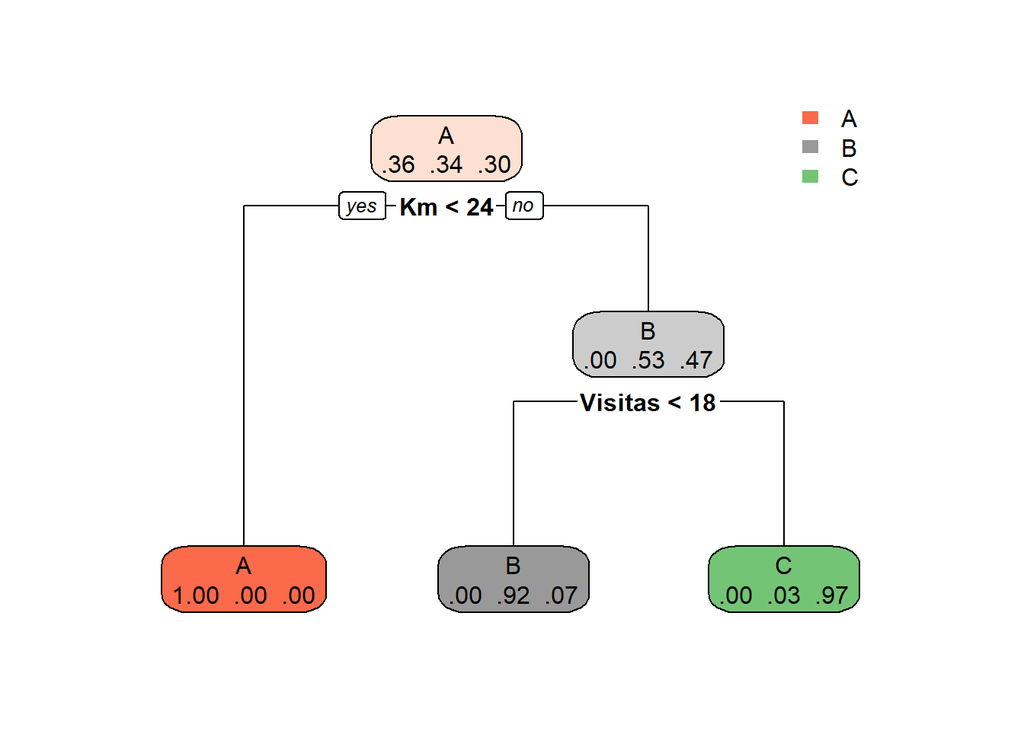

```r
#Obtenemos el arbol con un diseÃ±o grafico cuidado
f13<-rpart.plot(ArbolRpart_ctree,extra=4) #visualizamos el arbol
```

```r
f13
```

[output not shown]

[output cut: 23 more lines]

[output not shown]

```r
# Estudiamos la evolucion del error a medida que el arbol va creciendo
summary(ArbolRpart_ctree) # estadisticas detalladas de cada nodo
```

```
## Call:
## rpart(formula = ArbolRpart, data = trainData, method = "class")
##   n= 112
##
##          CP nsplit  rel error     xerror       xstd
## 1 0.5277778      0 1.00000000 1.15277778 0.06438675
## 2 0.4166667      1 0.47222222 0.55555556 0.07042952
## 3 0.0100000      2 0.05555556 0.08333333 0.03309688
##
## Variable importance
##  Visitas       Km Ingresos   Margen
##       34       31       21       14
##
## Node number 1: 112 observations,    complexity param=0.5277778
##   predicted class=A  expected loss=0.6428571  P(node) =1
##     class counts:    40    38    34
##    probabilities: 0.357 0.339 0.304
##   left son=2 (40 obs) right son=3 (72 obs)
##   Primary splits:
##       Km       < 24.5 to the left,  improve=38.61111, (0 missing)
##       Visitas  < 8    to the left,  improve=38.61111, (0 missing)
##       Ingresos < 5450 to the left,  improve=27.51111, (0 missing)
##       Margen   < 305  to the right, improve=16.75806, (0 missing)
##   Surrogate splits:
##       Visitas  < 8    to the left,  agree=1.000, adj=1.00, (0 split)
##       Ingresos < 5450 to the left,  agree=0.929, adj=0.80, (0 split)
##       Margen   < 335  to the right, agree=0.839, adj=0.55, (0 split)
##
## Node number 2: 40 observations
##   predicted class=A  expected loss=0  P(node) =0.3571429
##     class counts:    40     0     0
##    probabilities: 1.000 0.000 0.000
##
## Node number 3: 72 observations,    complexity param=0.4166667
##   predicted class=B  expected loss=0.4722222  P(node) =0.6428571
##     class counts:     0    38    34
##    probabilities: 0.000 0.528 0.472
##   left son=6 (40 obs) right son=7 (32 obs)
##   Primary splits:
##       Visitas  < 17.5 to the left,  improve=28.401390, (0 missing)
##       Km       < 47.5 to the left,  improve=25.263500, (0 missing)
##       Ingresos < 7050 to the left,  improve= 6.469534, (0 missing)
##       Margen   < 295  to the left,  improve= 2.688889, (0 missing)
##   Surrogate splits:
##       Km       < 47.5 to the left,  agree=0.917, adj=0.812, (0 split)
##       Ingresos < 6350 to the left,  agree=0.708, adj=0.344, (0 split)
##       Margen   < 295  to the left,  agree=0.667, adj=0.250, (0 split)
##
## Node number 6: 40 observations
##   predicted class=B  expected loss=0.075  P(node) =0.3571429
##     class counts:     0    37     3
##    probabilities: 0.000 0.925 0.075
##
## Node number 7: 32 observations
##   predicted class=C  expected loss=0.03125  P(node) =0.2857143
##     class counts:     0     1    31
##    probabilities: 0.000 0.031 0.969
```

```r
printcp(ArbolRpart_ctree) # estadisticas de resultados
```

```
##
## Classification tree:
## rpart(formula = ArbolRpart, data = trainData, method = "class")
##
## Variables actually used in tree construction:
## [1] Km      Visitas
##
## Root node error: 72/112 = 0.64286
##
## n= 112
##
##        CP nsplit rel error   xerror     xstd
## 1 0.52778      0  1.000000 1.152778 0.064387
## 2 0.41667      1  0.472222 0.555556 0.070430
## 3 0.01000      2  0.055556 0.083333 0.033097
```

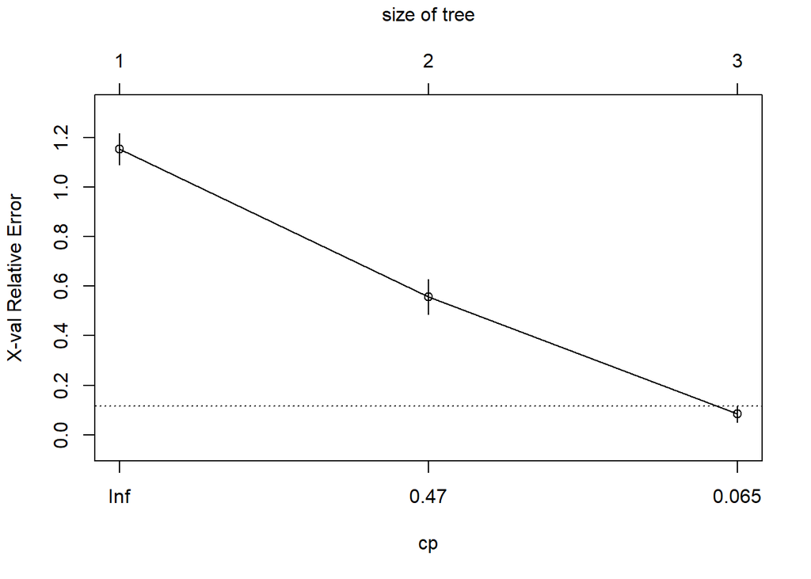

```r
plotcp(ArbolRpart_ctree) # evolucion del error a medida que se incrementan los nodos
```

```r
# Validamos la capacidad de prediccion del arbol con el fichero de validacion
testPredRpart <- predict(ArbolRpart_ctree, newdata = testData, type = "class")
# Visualizamos una matriz de confusion
table(testPredRpart, testData$Comercial)
```

```
##
## testPredRpart  A  B  C
##             A 10  0  0
##             B  0 12  2
##             C  0  0 14
```

```r
# Calculamos el % de aciertos
sum(testPredRpart == testData$Comercial)/ length(testData$Comercial)*100
```

```
## [1] 94.73684
```

El arbol de decision obtenido mediante el paquete *rpart* clasifica correctamente un 94,73% de los registros. Un resultado bastante alto y aceptable.

Una vez construida una primera version del arbol, estudiamos la viabilidad de un podado de arbol.

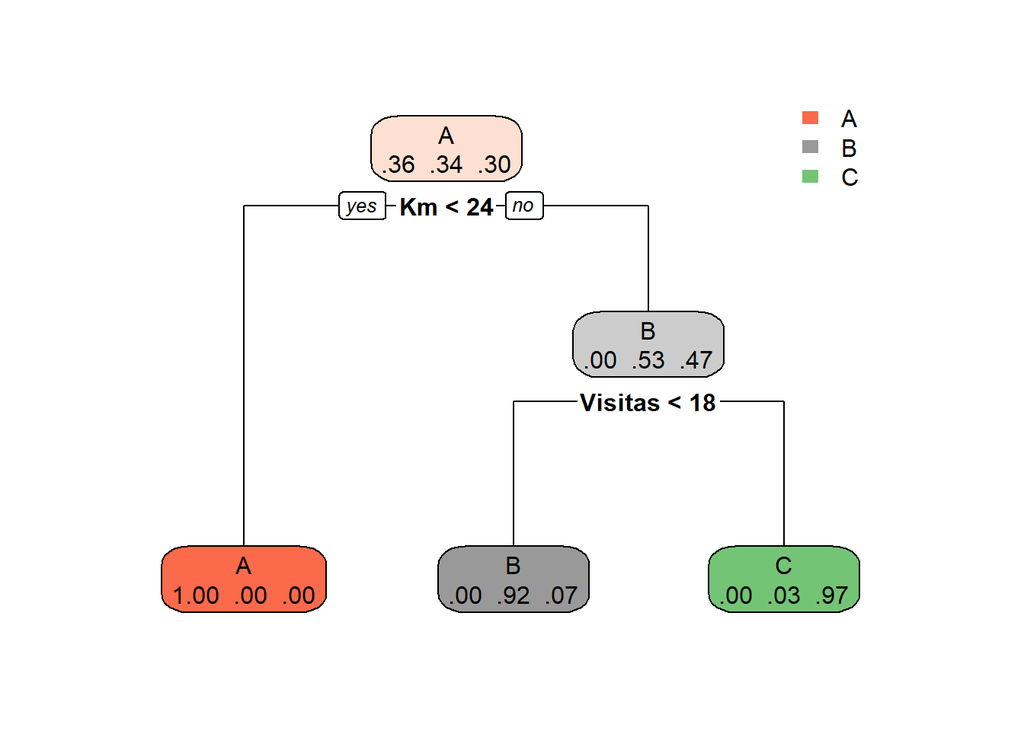

```r
# Podado del arbol
pArbolRpart_ctree<- prune(ArbolRpart_ctree, cp= ArbolRpart_ctree$cptable[which.min(ArbolRpart_ctree$cptable[,"xerror"]),"CP"])
  pArbolRpart_ctree<- prune(ArbolRpart_ctree, cp= 0.02)
# Representacion del arbol podado
f14<-rpart.plot(pArbolRpart_ctree,extra=4) #visualizamos el arbol
```

```r
f14
```

[output not shown]

[output cut: 23 more lines]

[output not shown]

Dado que el arbol original es muy simple. El podado no devuelve ninguna version nueva reducida.

# 7 Proceso de clasificacion mediante arboles de decision multimples (paquete randomForest)

Una vez evaluada la capacidad predictiva del algoritmo *K-NN*, y los arboles de decision simples obtenidos mediante el paquete *rpart*, estimamos el modelo que obtendriamos si ejecutasemos *n* arboles de decision simultaneamente (para *n*=100 en nuestro caso) mediante el algoritmo *randomForest*.

El algoritmo *randomForest* es un metodo de estimacion combinado, donde el resultado de la estimacion se construye a partir de los resultados obtenidos mediante el calculo de *n* arboles donde los predictores son incluidos al azar.

Es un metodo complejo con ventajas e inconvenientes respecto a los arboles de clasificacion simples:

*Ventajas*

- Es uno de los algoritmos de aprendizaje mas precisos
- Se ejecuta eficientemente en grandes bases de datos
- Permite trabajar con cientos de variables independientes sin excluir ninguna
- Determina la importancia en la clasificacion de cada variable
- Recupera eficazmente los valores perdidos de un dataset (*missings*)
- Permite evaluar la ganancia en clasificacion obtenida a medida que incrementamos el numero de arboles generados en el modelo.

*Inconvenientes*

- A diferencia de los arboles de decision, la clasificacion hecha por *random forests* es dificil de interpretar
- Favorece las variables categoricas que tienen un mayor numero de niveles por encima de aquellas que tienen un numero de categoria mas reducido. Comprometiendo la fiabilidad del modelo para este tipo de datos.
- Favorece los grupos mas pequenos cuando las variables estan correlacionadas
- randomForest sobreajusta en ciertos grupos de datos con tareas de clasificacion/regresion ruidosas

```r
# Dividimos el fichero en 70% entreno y 30% validacion  (parte recurrente en todo experimento)
set.seed(1234)
ind <- sample(2, nrow(Data_PEC2), replace=TRUE, prob=c(0.7, 0.3))
trainData <- Data_PEC2[ind==1,]
testData <- Data_PEC2[ind==2,]
#Declaramos funcion del arbol
ArbolRF <- Comercial ~ Ingresos + Margen + Km + Visitas
#Aplicamos algoritmo
ArbolRF_ctree <- randomForest(ArbolRF, data=trainData, ntree=100,proximity=T) #indicamos el numero de arboles mediante ntree=100
#Obtenemos la importancia de cada variable en el proceso de clasificacion
importance(ArbolRF_ctree)      #Importancia de las variables en formato text
```

```
##          MeanDecreaseGini
## Ingresos         7.109809
## Margen           1.339286
## Km              29.658770
## Visitas         35.781182
```

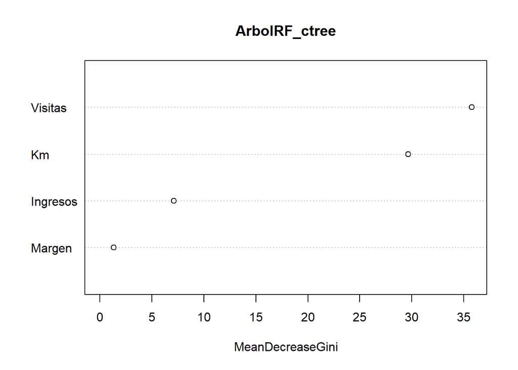

```r
f15<-varImpPlot(ArbolRF_ctree) #Importancia de las variables en formato grafico
```

```r
f15
```

```
##          MeanDecreaseGini
## Ingresos         7.109809
## Margen           1.339286
## Km              29.658770
## Visitas         35.781182
```

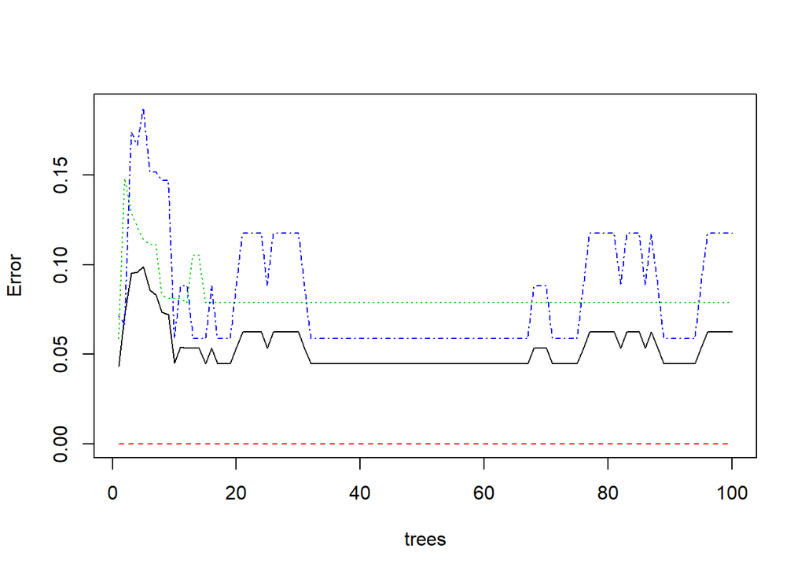

```r
#evolucion del error segun el numero de arboles
f16<-plot(ArbolRF_ctree, main = "")
```

```r
head(f16)
```

```
##             OOB A          B          C
## [1,] 0.04347826 0 0.05882353 0.07142857
## [2,] 0.07246377 0 0.14814815 0.06666667
## [3,] 0.09523810 0 0.12903226 0.17391304
## [4,] 0.09574468 0 0.12121212 0.16666667
## [5,] 0.09900990 0 0.11428571 0.18750000
## [6,] 0.08571429 0 0.11111111 0.15151515
```

```r
# Validamos la capacidad de prediccion del arbol con el fichero de validacion
  testPredRF <- predict(ArbolRF_ctree, newdata = testData)
  table(testPredRF, testData$Comercial)
```

```
##
## testPredRF  A  B  C
##          A 10  0  0
##          B  0 12  2
##          C  0  0 14
```

```r
# Calculamos el % de aciertos
sum(testPredRF == testData$Comercial)/ length(testData$Comercial)*100
```

```
## [1] 94.73684
```

El arbol de decision obtenido mediante el paquete *randomForest* clasifica correctamente un 94,73% de los registros. Un resultado bastante alto y aceptable.